# Plots

# Setup

```r
rm(list = ls())

library(tidyverse)
library(here)
library(ape)
library(tidytree)
library(ggtree)
library(ggplot2)
library(gridExtra)  # To put plots into a grid
library(patchwork)  # Also to put plots into grids. I'm not sure which one I actually ended up using
library(ggh4x)      # This helps bend ggplot to my will
library(ggnewscale) # This allows for multiple scales for the same aesthetic
library(GGally)     # For ggpairs
library(Rtsne)
library(phytools)
library(pals)       # nerdy colour palettes
library(forcats)
library(scales)
library(MASS)       # For nb regression lines on plots
set.seed(302)

select <- dplyr::select

languages <- c("Anindilyakwa",
               "Innu",
               # "Rangi",
               "Saami",
               "Tlingit",
               "Tobelo",
               "Tzeltal",
               "Zapotec")

languages_plus <- c("Anindilyakwa",
               "Innu",
               # "Rangi",
               "Saami",
               "Tlingit",
               "Tobelo",
               "Tzeltal",
               "Zapotec",
               "All")

colour_pairs <- list(
  Anindilyakwa = c("#ff1493", "#8b0a50"),       #deeppink
  Innu = c("#ff3030", "#cd2626"),         #firebrick
  Saami = c("#ff7f00", "#cd6600"),              #darkorange
  Tlingit = c("#FFD700", "#cdad00"),              #gold
  Tobelo = c("#00ee76", "#008b45"),            #springgreen
  # Tobelo = c("#00e5ee", "#00c5cd"),             #turquoise
  Tzeltal = c("#1e90ff", "#104e8b"),            #dodgerblue
  Zapotec = c("#bf3eff", "#68228b"),             #darkorchid
  All = c( "#b39bc9", "#675875")
  )

colour_1 <- sapply(colour_pairs, `[`, 1)
colour_2 <- sapply(colour_pairs, `[`, 2)
```

# Import data

```r
# Import similarity data and take out duplicates then re-scale everything else

bird_similarity <- list()

for (language in languages) {

  file_path <- here("data", paste0("similarity_", language, ".csv"))
  similarity <- read.csv(file = file_path) %>%
    select(-X) %>%
    mutate(Language = language) %>%
    # change names so I can identify duplicates
    mutate_at(vars(contains("Species")),
              ~gsub("\\..*", "", .)) %>%
    # make sure that the pairs are always identifiable as the same pairs (I did this when I created the dataset but doing it again just in case)
    mutate(s1 = pmin(Species1,Species2),
           s2 = pmax(Species1,Species2)) %>%
    select(-contains("Species")) %>%
    rename(Species1 = s1,
           Species2 = s2) %>%
    # Put the TRUE values before the FALSE ones so they will be the ones that remain when I remove duplicates
    arrange(desc(SameName)) %>%
    # filter out duplicated pairs
    distinct(Species1, Species2, .keep_all = TRUE) %>%
    #filter out birds pairing with themselves
    filter(Species1 != Species2) %>%
    select(-contains("zDist")) %>%
    mutate_at(vars(starts_with("Dist")), list(z = ~scale(.)[,1])) %>%
    rename_at(vars(ends_with("_z")), ~sub("(.*)_z$", "z\\1", .))

  result <- length(which(duplicated(similarity[,c("Species1","Species2")])))

      if (result == 0) {
    message("No duplicates remain in ", language)
      } else {

        message("Oh no,", language, "still has duplicates!")
      }

  bird_similarity[[language]] <- similarity

}
```

```
No duplicates remain in Anindilyakwa
```

```
No duplicates remain in Innu
```

```
No duplicates remain in Saami
```

```
No duplicates remain in Tlingit
```

```
No duplicates remain in Tobelo
```

```
No duplicates remain in Tzeltal
```

```
No duplicates remain in Zapotec
```

```r
# Make a master dataset with similarity of everything together

all_sim <- reduce(bird_similarity, rbind)

all_similarity <- all_sim %>%
  mutate(Language = "All")

all_similarity <- rbind(all_sim, all_similarity) %>%
  mutate(Language = factor(Language))

# Import bird isolation data, take out duplicates

bird_data <- read.csv(here("data/bird_data.csv")) %>%
  filter(Language %in% languages) %>%
  group_by(Language) %>%
  arrange(n) %>%
  distinct(ScientificName2023, .keep_all = TRUE) %>%
  select(-starts_with("zIso")) %>%
  mutate_at(vars(starts_with("Iso")), list(z = ~scale(.)[,1])) %>%
  rename_at(vars(ends_with("_z")), ~sub("(.*)_z$", "z\\1", .)) %>%
  ungroup()

all_data <- bird_data %>%
  mutate(Language = "All")

all_data <- rbind(bird_data,all_data) %>%
  mutate(Language = factor(Language))

# old_data <- read.csv(here("data/old_bird_data.csv"))
```

# Descriptive Stats

## Correlations between similarity predictors

```r
correlation_plots <- list()

  facet_labels <- c(
  "zDist74" = "1974",
  "zDist23" = "2023",
  "zDistPhy" = "Phy",
  "zDistPer" = "Per"
  # ,
  # "zDistCol" = "Col"
)

for (language in languages) {

  print(language)

  language_data <- bird_similarity[[language]]
  cols <- grep("^z", names(language_data), value = TRUE)
  range <-  range(language_data[,cols], na.rm = TRUE)
  colours <- colour_pairs[[language]]

  plot <- ggpairs(language_data,
                  columns = cols,
                  mapping = aes(colour = SameName,
                                alpha = .6,
                                size = SameName,
                                shape = SameName),
                  labeller = as_labeller(facet_labels),
                  lower = list(
                    continuous = wrap("points",
                                      position = position_jitter(height = .4,
                                                                 width = .4))),
                  diag = list(continuous = wrap("densityDiag",
                                              colour = "black",
                                              linewidth = .1)),
                  upper = list(continuous = wrap("cor",
                                                 size = 3,
                                                 digits = 2))
                  ) +
    theme_bw() +
    theme(plot.background = element_rect(fill = "white"),
          panel.background = element_rect(fill = "white"),
          panel.grid = element_blank(),
          axis.text.x = element_blank(),
          axis.text.y = element_blank(),
          axis.ticks = element_blank(),
          panel.spacing = unit(0.1, "lines")
        ) +
    scale_colour_manual(values = c(colours[1], "black")) +
    scale_fill_manual(values = c(colours[1], "black")) +
    scale_size_manual(values = c(.01, .5)) +
    scale_shape_manual(values = c(16, 17))

  correlation_plots[[language]] <- plot

  ggsave(here(paste0("output/pairs_plot_", language, ".png")),
       plot,
       width = 5,
       height = 4,
       dpi = 300)

}
```

```
[1] "Anindilyakwa"
```

[output not shown]

```
[1] "Innu"
```

[output not shown]

```
[1] "Saami"
```

[output not shown]

```
[1] "Tlingit"
```

[output not shown]

```
[1] "Tobelo"
```

[output not shown]

```
[1] "Tzeltal"
```

[output not shown]

```
[1] "Zapotec"
```

[output not shown]

[output not shown]

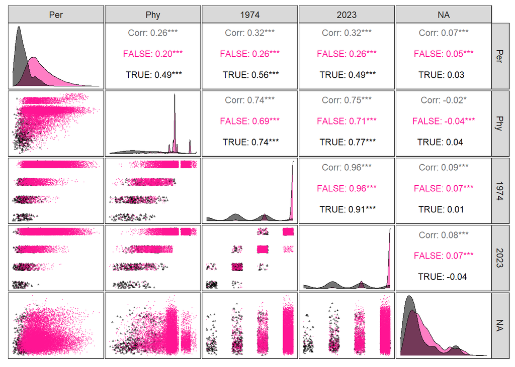

```r
correlation_plots[["Anindilyakwa"]]
```

## Distributions of predictors

### Isolation predictors

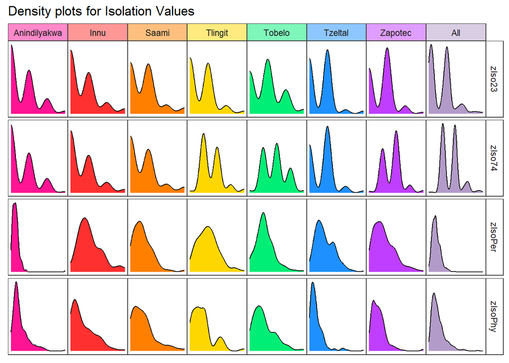

```r
iso_plot <- all_data %>%
  select(CanonicalName, Language, contains("zIso"), -zIsoCol) %>%
  pivot_longer(cols = contains("zIso"),
               names_to = "Variable",
               values_to = "Value") %>%
  ggplot(mapping = aes(Value,
                       fill = Language)) +
  geom_density() +
  scale_fill_manual(values = colour_1) +
  facet_grid2(Variable ~ factor(Language, levels = languages_plus),
              scales = "free",
              independent = "x",
              strip = strip_themed(
                background_x = elem_list_rect(fill = alpha(colour_1, .5)))) +
  theme_bw() +
  theme(axis.text.x = element_blank(),
        axis.text.y = element_blank(),
        axis.ticks = element_blank(),
        legend.position = "none",
        panel.spacing = unit(0, "lines"),
        panel.grid.major = element_blank(),
        panel.grid.minor = element_blank(),
        strip.background.y = element_rect(fill = "white")) +
  labs(x = NULL,
       y = NULL,
       title = "Density plots for Isolation Values")

ggsave(here("output/iso_plot.png"),
         iso_plot,
         width =15,
         height = 10,
         dpi = 500)

iso_plot
```

## Distributions of AVONET variables

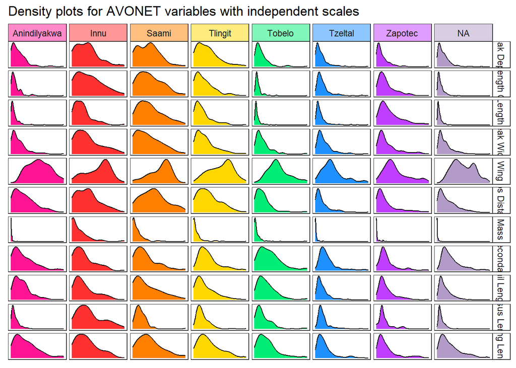

```r
avo_plot <- all_data %>%
  select(CanonicalName, Language, BeakLengthCulmen:Mass) %>%
  rename_with(~gsub("([a-z])([A-Z])", "\\1 \\2", .), BeakLengthCulmen:Mass) %>%
  pivot_longer(cols = "Beak Length Culmen": Mass,
               names_to = "Variable",
               values_to = "Value") %>%
  ggplot(mapping = aes(Value,
                       # colour = Language,
                       fill = Language)) +
  geom_density() +
    scale_fill_manual(values = colour_1) +
  facet_grid2(Variable ~ factor(Language, levels = languages),
              scales = "free",
              independent = "all",
              strip = strip_themed(
                background_x = elem_list_rect(fill = alpha(colour_1, .5)))) +
  theme_bw() +
  theme(axis.text.x = element_blank(),
        axis.text.y = element_blank(),
        axis.ticks = element_blank(),
        legend.position = "none",
        panel.spacing = unit(0, "lines"),
        panel.grid.major = element_blank(),
        panel.grid.minor = element_blank(),
        strip.background.y = element_rect(fill = "white")) +
  labs(x = NULL,
       y = NULL,
       title = "Density plots for AVONET variables with independent scales")


  ggsave(here("output/avo_plot.png"),
         avo_plot,
         width =10,
         height = 15,
         dpi = 500)

avo_plot
```

## Distributions of AVONET variables - fixed scales

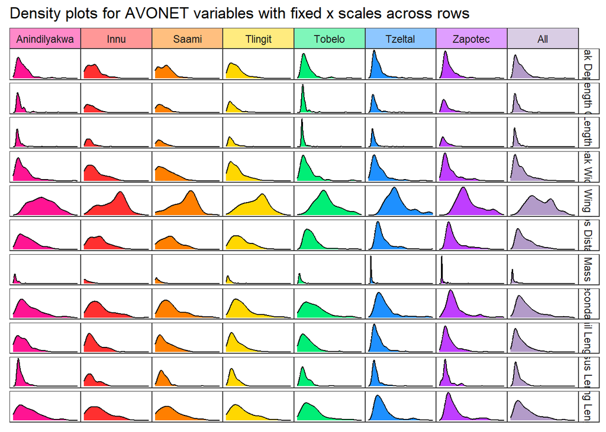

```r
avo_plot_2_data <- all_data %>%
  filter(zIsoPer < 8) %>%
  select(CanonicalName, Language, BeakLengthCulmen:Mass) %>%
  group_by(Language) %>%
  mutate(across(BeakLengthCulmen:Mass, list(z = ~scale(.)[,1]))) %>%
  ungroup()%>%
  select(-c(BeakLengthCulmen:Mass)) %>%
  rename_with(~gsub("_z","", .), BeakLengthCulmen_z:Mass_z)%>%
  rename_with(~gsub("([a-z])([A-Z])", "\\1 \\2", .), BeakLengthCulmen:Mass)

ranges <- avo_plot_2_data %>%
  summarise(across("Beak Length Culmen":Mass,
                   list(min = ~min(., na.rm = TRUE),
                        max = ~max(., na.rm = TRUE)))) %>%
  mutate(Language = NA)

ranges_full <- data.frame()

for (language in languages_plus) {

  lang <- str_to_title(language)
  ranges_lang <- ranges %>% mutate(Language = lang)
  ranges_full <- rbind(ranges_full, ranges_lang)

}

ranges_full <- ranges_full %>%
  pivot_longer(cols = -Language,
               names_to = "Variable",
               values_to = "Value") %>%
  mutate(Variable = gsub("_.*", "", Variable))

avo_plot_2_data_long <- avo_plot_2_data %>%
    pivot_longer(cols = "Beak Length Culmen": Mass,
               names_to = "Variable",
               values_to = "Value")

  avo_plot_2 <- avo_plot_2_data_long %>%
    ggplot(mapping = aes(Value,
                       # colour = Language,
                       fill = Language)) +
    geom_density() +
    scale_fill_manual(values = colour_1) +
    geom_point(data = ranges_full,
               aes(x = Value, y = 0), alpha = 0)  +
    # This bit of ridiculosity is just so I can fix the x-scales across rows
  facet_grid2(Variable ~ factor(Language, levels = languages_plus),
              scales = "free",
              independent = "x",
              strip = strip_themed(
                background_x = elem_list_rect(fill = alpha(colour_1, .5)))) +
  theme_bw() +
  theme(
    axis.text.x = element_blank(),
        axis.text.y = element_blank(),
        axis.ticks = element_blank(),
        legend.position = "none",
        panel.spacing = unit(0, "lines"),
        panel.grid.major = element_blank(),
        panel.grid.minor = element_blank(),
        strip.background.y = element_rect(fill = "white")) +
  labs(x = NULL,
       y = NULL,
       title = "Density plots for AVONET variables with fixed x scales across rows")

  ggsave(here("output/avo_plot_2.png"),
         avo_plot_2,
         width =10,
         height = 15,
         dpi = 500)

avo_plot_2
```

# Analysis 1: Predicting name-sharing

## Violin plots individual predictors

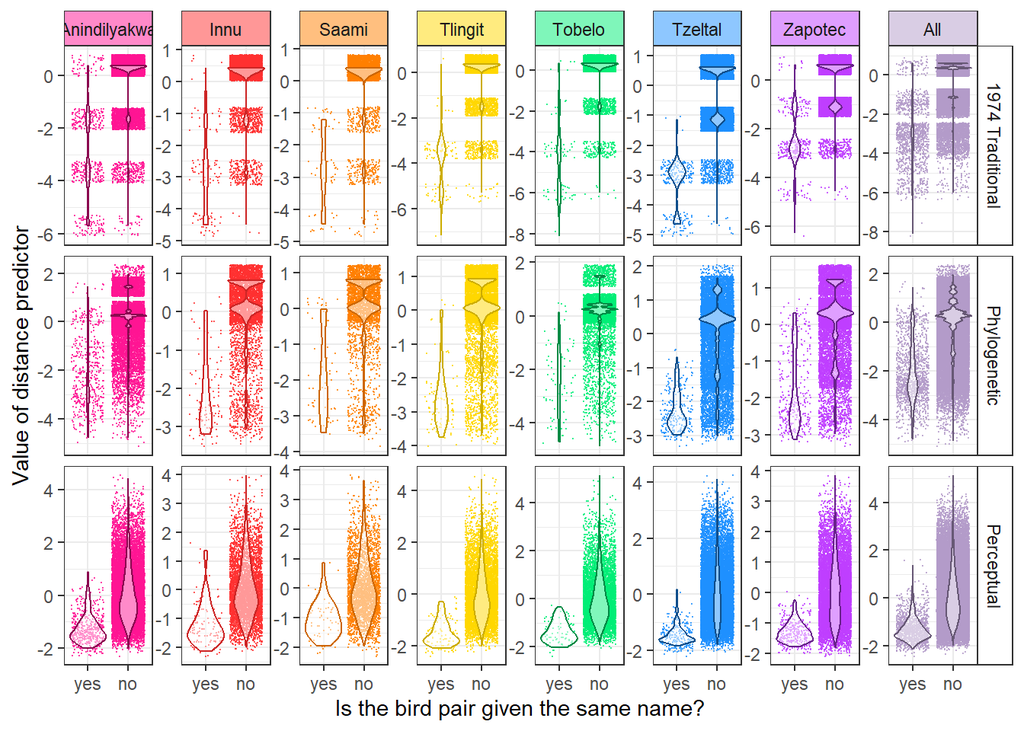

```r
plot_data <- all_similarity %>%
  pivot_longer(cols = c(zDistPer,
                        zDistPhy,
                        # zDist23,
                        zDist74),
               values_to = "Value",
               names_to = "Variable") %>%
  mutate(SameName = ifelse(SameName == TRUE,
                           "yes",
                           "no"),
         Variable = case_when(
           Variable == "zDistPer" ~ "Perceptual",
           Variable == "zDistPhy" ~ "Phylogenetic",
           Variable == "zDist74" ~ "1974 Traditional",
           # Variable == "zDist23" ~ "2023 Traditional",
           TRUE ~ Variable
         ))

plot_violin2 <- plot_data %>%
  ggplot(mapping = aes(factor(SameName, levels = c("yes","no")), Value,
                       colour = Language)) +
  geom_point(position = position_jitter(width = 0.4,
                                             height = 0.4),
                  size = 0.01,
                  alpha = 0.7,
                  aes(colour = Language)) +
   scale_colour_manual(values = colour_1) +
  new_scale_color() +
  geom_violin(fill = "white",
              alpha = .5,
              aes(colour = Language)) +

  scale_colour_manual(values = colour_2) +
  facet_grid2(factor(Variable,
                     levels = c("1974 Traditional",
                                # "2023 Traditional",
                                "Phylogenetic",
                                "Perceptual")) ~
                       factor(Language,
                              levels = languages_plus),
              scales = "free",
              independent = "y",
              strip = strip_themed(
     background_x = elem_list_rect(fill = alpha(colour_1, .5)))) +
# Customise the number of integer breaks - this argument is life changing and I am obsessed with it.
  scale_y_continuous(breaks = breaks_pretty(n = 5, min.n = 1),
                     labels = label_number(accuracy = 1)) +
  theme_bw() +
  theme(legend.position = "none",
        strip.background.y = element_rect(fill = "white"),
        panel.spacing.x=unit(.1, "lines")) +
  ylab("Value of distance predictor") +
  xlab("Is the bird pair given the same name?")

  plot_violin2
```

```r
    ggsave(here("output/violin_LR.png"),
         plot_violin2,
         width = 8,
         height = 5,
         dpi = 300)
```

# Analysis 2: Predicting singleton categories

## Violin plots for logistic regression

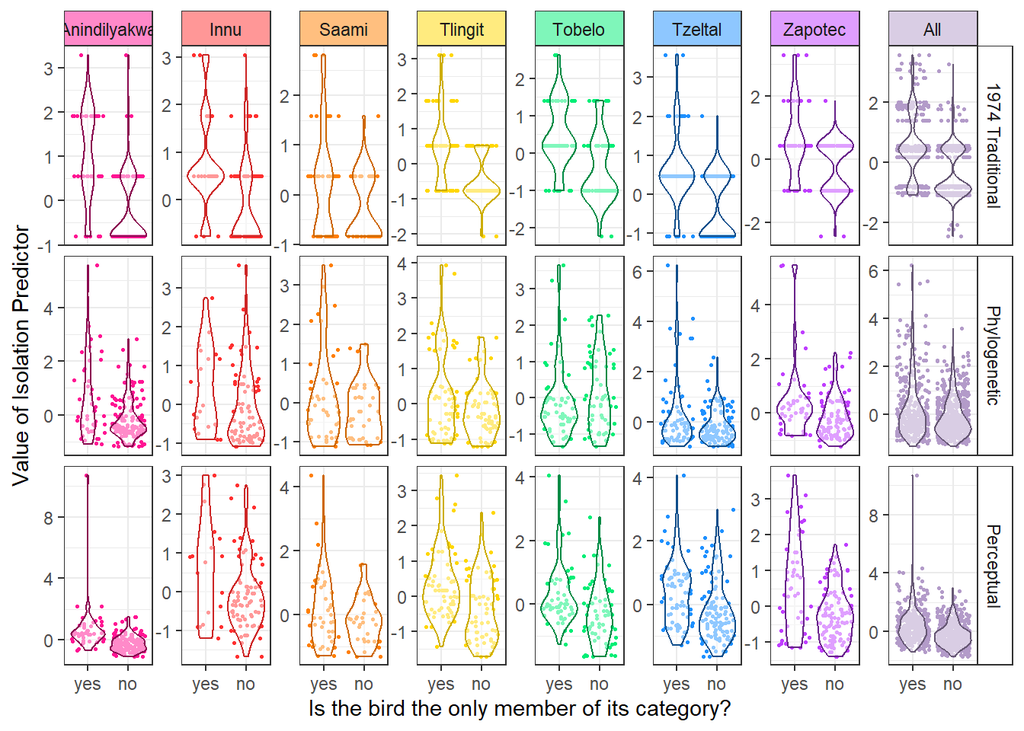

```r
vars <- c("zIso74",
          # "zIso23",
          "zIsoPhy",
          "zIsoPer")

labels <- c("1974 Traditional",
            # "2023 Traditional",
            "Phylogenetic",
            "Perceptual")

plot_data <- all_data %>%
  mutate(Monotypic = ifelse(
    n == 1, "yes", "no"
  )) %>%
  select(Language, Monotypic, all_of(vars)) %>%
  pivot_longer(cols = all_of(vars),
               names_to = "pred",
               values_to = "value") %>%
      mutate(pred = case_when(
    pred == "zIso74" ~ "1974 Traditional",
    # pred == "zIso23" ~ "2023 Traditional",
    pred == "zIsoPer" ~ "Perceptual",
    pred == "zIsoPhy" ~ "Phylogenetic",
    TRUE ~ pred  # Default to keep original value if no match
  ))

violin_2 <- plot_data %>%
  ggplot(mapping = aes(factor(Monotypic, levels = c("yes", "no")), value, colour = Language, fill = Language)) +
  geom_point(position = position_jitter(width = 0.4),
             size = 0.5) +
  scale_colour_manual(values = colour_1) +
  new_scale_color() +
  # geom_boxplot(alpha = .5,
  #              outlier.shape = 21,
  #              fill = "white",
  #              aes(colour = Language)) +
  geom_violin(alpha = .5,
              fill = "white",
              aes(colour = Language))+
  scale_colour_manual(values = colour_2) +
  facet_grid2(factor(pred, levels = labels) ~
                factor(Language, levels = languages_plus),
              scales = "free",
              independent = "y",
              strip = strip_themed(
                background_x = elem_list_rect(fill = alpha(colour_1, .5)))) +
  theme_bw() +
  theme(legend.position = "none",
        strip.background.y = element_rect(fill = "white")) +
  ylab("Value of Isolation Predictor") +
  xlab("Is the bird the only member of its category?") +
  theme(panel.spacing.x=unit(.1, "lines"))

ggsave(here("output/violin_monotypic.png"),
       violin_2,
       width = 9,
       height = 5,
       dpi = 300)

violin_2
```

# Analysis 2a: Predicting companion count

## Predictions from models

These predictions come from nb models, with predictions from the truncated NB models added to see how they perform when not considering the monotypic birds

At the moment the predictions have the emu taken out. Unless I have changed it but not changed this line.

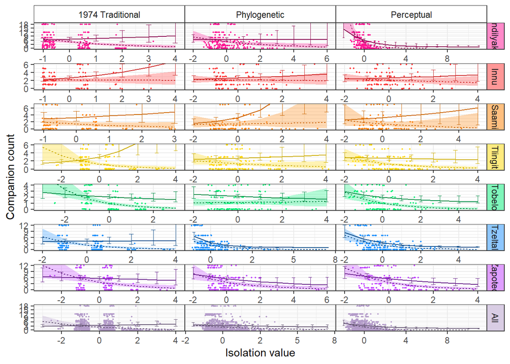

```r
# This is the long skinny version of the plot

# Import prediction data for negative binomial models (full data)
preds_nb <- read_csv(here("data/Predictions_nb.csv"),
                     show_col_types = FALSE) %>%
  # pivot_longer(cols = "-2":"3",
  #              names_to = "value",
  #              values_to = "n") %>%
  mutate(name = case_when(
    Predictor == "zIso74" ~ "1974 Traditional",
    Predictor == "zIsoPer" ~ "Perceptual",
    Predictor == "zIsoPhy" ~ "Phylogenetic",
    TRUE ~ Predictor)) %>%
  mutate(value = as.numeric(value),
         n = as.numeric(n),
         group = "All data")
# Import prediction data for truncated negative binomial models (n=1 observations removed from the data)
preds_tnb <- read_csv(here("data/Predictions_tnb.csv"),
                     show_col_types = FALSE) %>%
  mutate(name = case_when(
    Predictor == "zIso74" ~ "1974 Traditional",
    Predictor == "zIsoPer" ~ "Perceptual",
    Predictor == "zIsoPhy" ~ "Phylogenetic",
    TRUE ~ Predictor)) %>%
  mutate(value = as.numeric(value),
         n = as.numeric(n),
         group = "Monotypic removed")

preds <- rbind(preds_nb, preds_tnb)

all_data <- bird_data %>%
  mutate(Language = "All")

plot_data <- bird_data %>%
  rbind(all_data)%>%
  select(zIso74,
    zIsoPhy,
    zIsoPer,
    CanonicalName,
    n,
    Language) %>%
  filter(zIsoPer<10) %>%  # take emu out
  pivot_longer(cols = c(
    zIso74,
    zIsoPhy,
    zIsoPer
  )) %>%
  mutate(name = case_when(
    name == "zIso74" ~ "1974 Traditional",
    name == "zIsoPer" ~ "Perceptual",
    name == "zIsoPhy" ~ "Phylogenetic",
    TRUE ~ name  # Default to keep original value if no match
  ))

# This is for ggh4x to set the limits of the facets separately
facet_limits <- plot_data %>%
  group_by(Language) %>%
  summarise(y_min = min(0), y_max = max(n)-1) %>%
  arrange(factor(Language, levels = languages))

scales_list <- facet_limits %>%
  mutate(
    # There is a better way of doing this but I didn't know it at the time so I am just leaving it because it works fine.
    scale = map2(y_min,
                 y_max,
                 ~scale_y_continuous(limits = c(.x, .y),
                                     breaks = seq(0, .y, by = ifelse(
                                       .y > 11, 3,
                                       ifelse(
                                         .y > 5.1,
                                           2, 1
                                         )
                                       )
                                     )))
  ) %>%
  pull(scale) %>%
  setNames(facet_limits$Language)

# This is to plot the error bars
confints_all <- preds %>%
  filter(group == "All data") %>%
  mutate(Model = ifelse(str_detect(Model, "CI"), Model, "Mean")) %>%
  pivot_wider(names_from = Model,
              values_from = n) %>%
  filter(complete.cases(.))

confints_nomono <- preds %>%
  filter(group == "Monotypic removed") %>%
  mutate(Model = ifelse(str_detect(Model, "CI"), Model, "Mean")) %>%
  pivot_wider(names_from = Model,
              values_from = n) %>%
  filter(complete.cases(.))

plot_preds <- plot_data %>%
  mutate(n = n - 1) %>%   # to make the nb the same as in the analysis - shifting it to start at 0
  ggplot(mapping = aes(y = (n),
                       x = value,
                       fill = Language)) +

  geom_point(shape = 21,
             stroke = NA,
             size = .7,
             position = position_jitter(width = 0.25, height = 0.08)) +
  facet_grid2(factor(Language, levels = languages_plus)
              ~ factor(name, levels = c("1974 Traditional",
                                        "Phylogenetic",
                                        "Perceptual")),
              scales = "free",
              independent = "x",
              # labeller = facet_labeller,
              strip = strip_themed(
     background_y = elem_list_rect(fill = alpha(colour_1, .5)))) +
  scale_colour_manual(values = colour_2) +
  theme_bw()  +
  scale_fill_manual(values = colour_1) +
  labs(x = "Isolation value",
       y = "Companion count") +
  facetted_pos_scales(y = scales_list) +
  new_scale_color() +
  geom_ribbon(data = confints_all,
              alpha = .3,
              aes(fill = Language,
                  y = Mean,
                  ymin = CI_lower,
                  ymax = CI_upper)) +
  geom_line(data = preds %>% filter(!str_detect(Model, "CI")),
            aes(colour = Language,
                group = group,
                linetype = factor(group,
                                  levels = c("Monotypic removed",
                                             "All data")))) +
  scale_colour_manual(values = colour_2) +
  geom_errorbar(data = confints_nomono,
                size = 0.2,
                aes(y = Mean,
                    ymin = CI_lower,
                    ymax = CI_upper,
                    x = value,
                    colour = Language,
                    width = .2)) +
  theme(legend.position = "none",
        legend.title = element_blank(),
        panel.spacing = unit(0, "lines"),
        strip.background.x = element_rect(fill = "white")) +
  guides(colour = FALSE, fill = FALSE) +
  scale_x_continuous(labels = label_number(accuracy = 1))
  ggsave(here("output/scatter_preds.png"),
         plot_preds,
         width = 4,
         height = 8,
         dpi = 500)
plot_preds
```

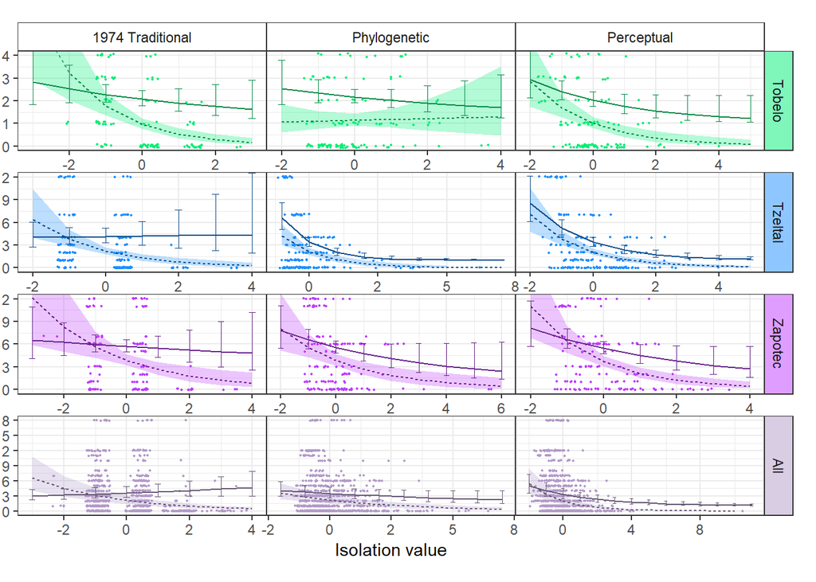

```r
# This is the wide version of the plots

# maybe a bit of a neater way to do it

# Import prediction data
preds_nb <- read_csv(here("data/Predictions_nb.csv")) %>%
  # pivot_longer(cols = "-2":"3",
  #              names_to = "value",
  #              values_to = "n") %>%
  mutate(name = case_when(
    Predictor == "zIso74" ~ "1974 Traditional",
    Predictor == "zIsoPer" ~ "Perceptual",
    Predictor == "zIsoPhy" ~ "Phylogenetic",
    TRUE ~ Predictor)) %>%
  mutate(value = as.numeric(value),
         n = as.numeric(n),
         group = "All data")
preds_tnb <- read_csv(here("data/Predictions_tnb.csv"),
                     show_col_types = FALSE) %>%
  mutate(name = case_when(
    Predictor == "zIso74" ~ "1974 Traditional",
    Predictor == "zIsoPer" ~ "Perceptual",
    Predictor == "zIsoPhy" ~ "Phylogenetic",
    TRUE ~ Predictor)) %>%
  mutate(value = as.numeric(value),
         n = as.numeric(n),
         group = "Monotypic removed")

preds <- rbind(preds_nb, preds_tnb)

all_data <- bird_data %>%
  mutate(Language = "All")

plot_data <- bird_data %>%
  rbind(all_data)%>%
  select(zIso74,
    zIsoPhy,
    zIsoPer,
    CanonicalName,
    n,
    Language) %>%
  # filter(zIsoPer<10) %>%  # take emu out
  pivot_longer(cols = c(
    zIso74,
    zIsoPhy,
    zIsoPer
  )) %>%
  mutate(name = case_when(
    name == "zIso74" ~ "1974 Traditional",
    name == "zIsoPer" ~ "Perceptual",
    name == "zIsoPhy" ~ "Phylogenetic",
    TRUE ~ name  # Default to keep original value if no match
  ))

# This is for ggh4x to set the limits of the facets separately
facet_limits <- plot_data %>%
  group_by(Language) %>%
  summarise(y_min = min(0), y_max = max(n)-1) %>%
  arrange(factor(Language, levels = languages))

scales_list <- facet_limits %>%
  mutate(
    scale = map2(y_min,
                 y_max,
                 ~scale_y_continuous(limits = c(.x, .y),
                                     breaks = seq(0, .y, by = ifelse(
                                       .y > 11, 3,
                                       ifelse(
                                         .y > 5.1,
                                           2, 1
                                         )
                                       )
                                     )))
  ) %>%
  pull(scale) %>%
  setNames(facet_limits$Language)

# This is to plot the error bars

confints_all <- preds %>%
  filter(group == "All data") %>%
  mutate(Model = ifelse(str_detect(Model, "CI"), Model, "Mean")) %>%
  pivot_wider(names_from = Model,
              values_from = n) %>%
  filter(complete.cases(.))

confints_nomono <- preds %>%
  filter(group == "Monotypic removed") %>%
  mutate(Model = ifelse(str_detect(Model, "CI"), Model, "Mean")) %>%
  pivot_wider(names_from = Model,
              values_from = n) %>%
  filter(complete.cases(.))



first_half <- languages_plus[1:(length(languages_plus)/2)]
second_half <- languages_plus[(length(languages_plus)/2+1):length(languages_plus)]

colour_1_2 <- colour_1[(length(colour_1)/2+1):length(colour_1)]


scales_list_2 <- scales_list[(length(scales_list)/2+1):length(scales_list)]


plot_preds_1 <- plot_data %>%
  filter(Language %in% first_half) %>%
  mutate(n = n-1) %>%   # to make the nb the same as in the analysis - shifting it to start at 0
  ggplot(mapping = aes(y = (n),
                       x = value,
                       fill = Language)) +
  geom_point(shape = 21,
             stroke = NA,
             size = .7,
             position = position_jitter(width = 0.25, height = 0.08))+
  facet_grid2(factor(Language, levels = first_half)
              ~ factor(name, levels = c("1974 Traditional",
                                        "Phylogenetic",
                                        "Perceptual")),
              scales = "free",
              independent = "x",
              # labeller = facet_labeller,
              strip = strip_themed(
     background_y = elem_list_rect(fill = alpha(colour_1, .5))))+
  scale_colour_manual(values = colour_2) +
  theme_bw()  +
  scale_fill_manual(values = colour_1) +
  labs(x = "Isolation value",
       y = "Companion count")+
   facetted_pos_scales(
    y = scales_list
  ) +
  new_scale_color() +
    geom_ribbon(data = confints_all %>% filter(Language %in% first_half),
                  alpha = .3,
              aes(fill = Language,
                  y = Mean,
                  ymin = CI_lower,
                  ymax = CI_upper)) +
  geom_line(data = preds %>% filter(!str_detect(Model, "CI") & Language %in% first_half),
            aes(colour = Language,
                group = group,
                linetype = factor(group, levels = c("Monotypic removed", "All data"))))+
  scale_colour_manual(values = colour_2) +
  geom_errorbar(data = confints_nomono %>% filter(Language %in% first_half),
                size = 0.2,
                aes(y = Mean,
                    ymin = CI_lower,
                    ymax = CI_upper,
                    x = value,
                    colour = Language,
                    width = .2)) +
  theme(legend.position = "none",
        legend.title = element_blank(),
        panel.spacing = unit(0, "lines"),
        strip.background.x = element_rect(fill = "white"),
        plot.margin = unit(c(.5,0,.5,.5), "cm")) +
  guides(colour = FALSE, fill = FALSE) +
  scale_x_continuous(labels = label_number(accuracy = 1))

# Second plot

plot_preds_2 <- plot_data %>%
  filter(Language %in% second_half) %>%
  mutate(n = n-1) %>%   # to make the nb the same as in the analysis - shifting it to start at 0
  ggplot(mapping = aes(y = (n),
                       x = value,
                       fill = Language)) +

  geom_point(shape = 21,
             stroke = NA,
             size = .7,
             position = position_jitter(width = 0.25, height = 0.08))+
  facet_grid2(factor(Language, levels = second_half)
              ~ factor(name, levels = c("1974 Traditional",
                                        "Phylogenetic",
                                        "Perceptual")),
              scales = "free",
              independent = "x",
              # labeller = facet_labeller,
              strip = strip_themed(
     background_y = elem_list_rect(fill = alpha(colour_1_2, .5))))+
  scale_colour_manual(values = colour_2) +
  theme_bw()  +
  scale_fill_manual(values = colour_1) +
  labs(x = "Isolation value",
       y = element_blank())+
   facetted_pos_scales(
    y = scales_list_2
  ) +
  new_scale_color() +
    geom_ribbon(data = confints_all %>% filter(Language %in% second_half),
                  alpha = .3,
              aes(fill = Language,
                  y = Mean,
                  ymin = CI_lower,
                  ymax = CI_upper)) +
  geom_line(data = preds %>%
              filter(!str_detect(Model, "CI") & Language %in% second_half),
            aes(colour = Language,
                group = group,
                linetype = factor(group, levels = c("Monotypic removed", "All data"))))+
  scale_colour_manual(values = colour_2) +
  geom_errorbar(data = confints_nomono %>% filter(Language %in% second_half),
                size = 0.2,
                aes(y = Mean,
                    ymin = CI_lower,
                    ymax = CI_upper,
                    x = value,
                    colour = Language,
                    width = .2)) +
  theme(legend.position = "none",
        legend.title = element_blank(),
        panel.spacing = unit(0, "lines"),
        strip.background.x = element_rect(fill = "white"),
        plot.margin = unit(c(.5,.5,.5,-0.3), "cm")) +
  guides(colour = FALSE, fill = FALSE) +
  scale_x_continuous(labels = label_number(accuracy = 1))

plot_preds_2
```

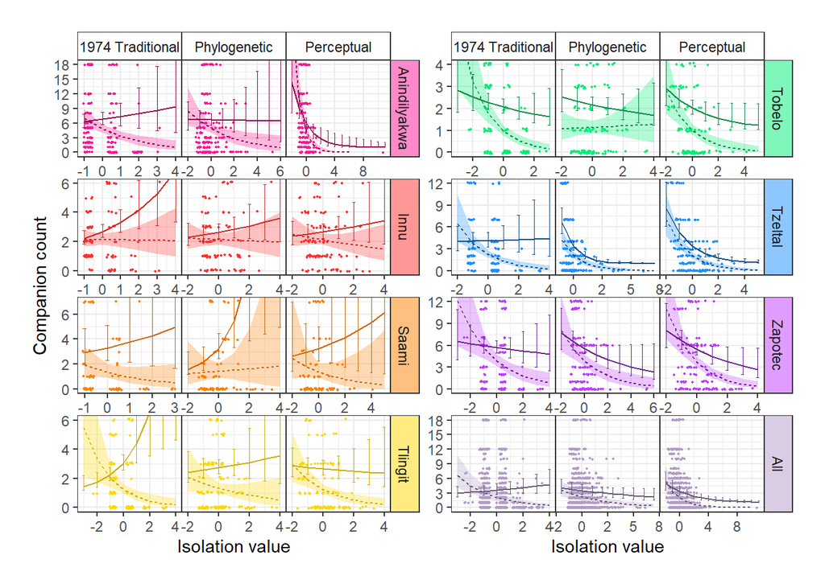

```r
both_plots <- list(plot_preds_1, plot_preds_2)

all_plots_together <-
  wrap_plots(both_plots, ncol = 2)

all_plots_together
```

```r
  ggsave(here("output/scatter_preds_patchwork.png"),
         all_plots_together,
         width = 8,
         height = 5,
         dpi = 500)
```

## Scatterplot of all languages together

[output not shown]

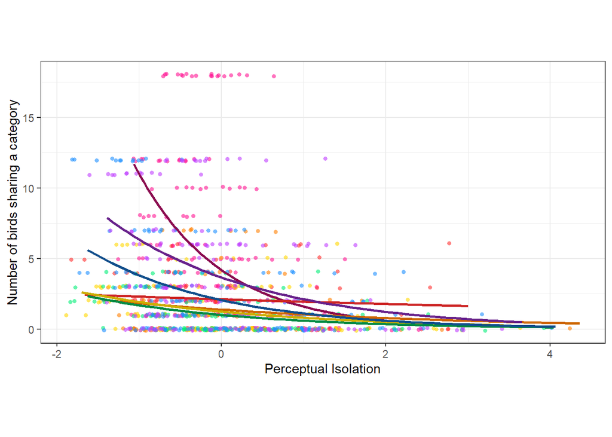

```r
# Perceptual isolation plot with all languages

mega_plot_per <- bird_data %>%
  filter(Language %in% languages) %>%
  mutate(n = n - 1) %>%
  filter(zIsoPer < 8) %>%
  ggplot(aes(y = n,
             x = zIsoPer,
             fill = Language,
             colour = Language)) +
  geom_point(shape = 21,
             stroke = NA,
             alpha = .6,
             position = position_jitter(width = 0.25, height = 0.1))+
  scale_fill_manual(values = colour_1) +
  geom_smooth(method = "glm.nb",
              se = FALSE,
              # fullrange = TRUE,
              aes(group = Language))+
  scale_colour_manual(values = colour_2)+
  theme_bw() +
  theme(
    # legend.position = "bottom",
    legend.position = "none",
        aspect.ratio = 1/2) +
  labs(y = "Number of birds sharing a category",
       x = "Perceptual Isolation")

mega_plot_per
```

[output not shown]

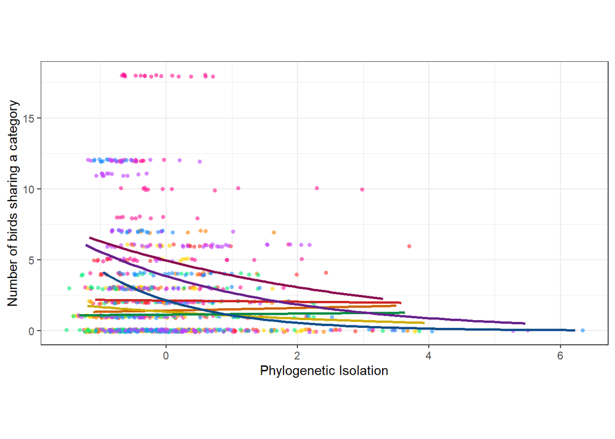

```r
# Phylogenetic isolation plot with all languages

mega_plot_phy <- bird_data %>%
  mutate(n = n - 1) %>%
  filter(zIsoPer<8) %>%
  ggplot(aes(y = n,
             x = zIsoPhy,
             fill = Language,
             colour = Language)) +
  geom_point(shape = 21,
             stroke = NA,
             alpha = .6,
             position=position_jitter(width=0.25, height=0.1)) +
  scale_fill_manual(values = colour_1) +
  geom_smooth(method = "glm.nb",
              se = FALSE,
              # fullrange = TRUE,
              aes(group = Language)) +
  scale_colour_manual(values = colour_2) +
  theme_bw() +
  theme(legend.position = "none",
        aspect.ratio = 1/2) +
  labs(y = "Number of birds sharing a category",
       x = "Phylogenetic Isolation")

mega_plot_phy
```

[output not shown]

[figure not shown]

```r
# Traditional plot with all languages

mega_plot_74 <- bird_data %>%
  mutate(n = n - 1) %>%
  # filter(zIsoPer < 8) %>%
  ggplot(aes(y = n,
             x = zIso74,
             fill = Language,
             colour = Language)) +
  geom_point(shape = 21,
             stroke = NA,
             alpha = .6,
             position = position_jitter(width = 0.25, height = 0.25))+
  scale_fill_manual(values = colour_1) +
  geom_smooth(method = "glm.nb",
              se = FALSE,
              # fullrange = TRUE,
              aes(group = Language))+
  scale_colour_manual(values = colour_2)+
  theme_bw() +
  theme(legend.position = "none",
        aspect.ratio = 1/2) +
  labs(x = "Number of birds sharing a category",
       y = "1974 Traditional Isolation")
mega_plot_74
```

[output not shown]

[figure not shown]

```r
facet_labels <- c(
  "zIso74" = "1974 Traditional",
  "zIsoPer" = "Perceptual",
  "zIsoPhy" = "Phylogenetic"
)
mega_plot_74
```

[output not shown]

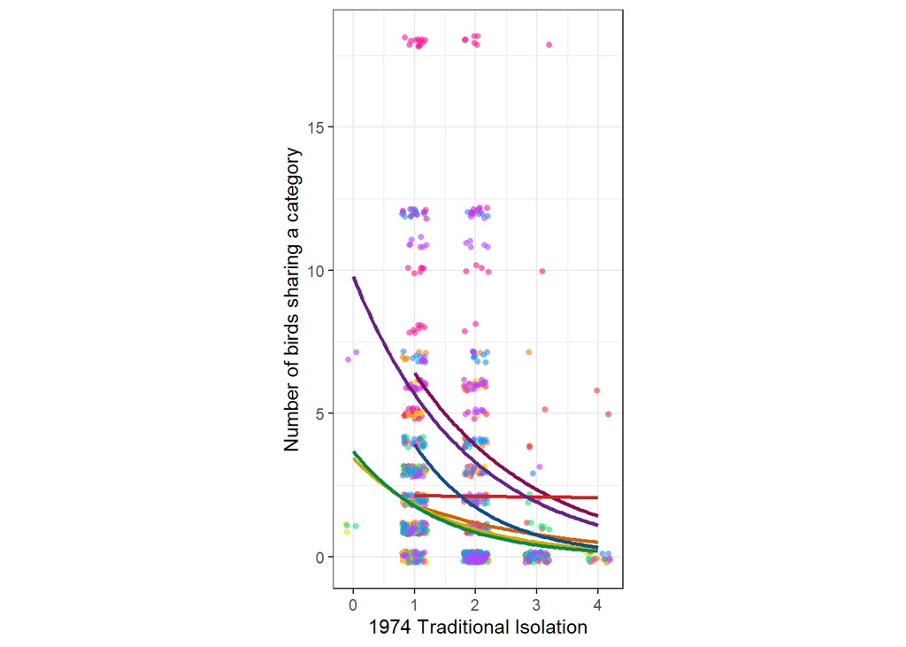

```r
# Traditional plot again but unscaled because I reckon it's better

mega_plot_74_unsc <- bird_data %>%
  mutate(n = n - 1) %>%
  # filter(zIsoPer < 8) %>%
  ggplot(aes(y = n,
             x = Iso74,
             fill = Language,
             colour = Language)) +
  geom_point(shape = 21,
             stroke = NA,
             position = position_jitter(width = 0.2, height = 0.2),
             alpha = .6
             )+
  scale_fill_manual(values = colour_1) +
  geom_smooth(method = "glm.nb",
              se = FALSE,
              # fullrange = TRUE,
              aes(group = Language))+
  scale_colour_manual(values = colour_2)+
  theme_bw() +
  theme(legend.position = "none",
        aspect.ratio = 2/1) +
  labs(y = "Number of birds sharing a category",
       x = "1974 Traditional Isolation")
mega_plot_74_unsc
```

```r
facet_labels <- c(
  "zIso74" = "1974 Traditional",
  "zIsoPer" = "Perceptual",
  "zIsoPhy" = "Phylogenetic"
)

facet_labeller <- function(variable,value){
  return(facet_labels[value])
}

x_range <- range(bird_data %>%
                     filter(zIsoPer < 8) %>%
                     select(zIso74, zIsoPhy,zIsoPer) %>%
                     unlist(), na.rm = TRUE)
x_ranges <- bird_data %>%
  ungroup() %>%
  select(zIso74, zIsoPhy, zIsoPer) %>%
  filter(zIsoPer < 8)%>%
  pivot_longer(cols = starts_with("z")) %>%
  group_by(name) %>%
  summarise(x_min = floor(min(value, na.rm = TRUE)),  # Example: using floor for x_min
            x_max = ceiling(max(value, na.rm = TRUE)))

x_mins <- x_ranges$x_min
x_maxs <- x_ranges$x_max

# This is to force the lines to be plotted in a particular order, so the shortest ones are on top and therefore easier to see
line_order <- bird_data %>% group_by(Language) %>%
  slice_max(n, with_ties = FALSE) %>%
  arrange(desc(n)) %>%
  pull(Language)

# This is to make the breaks at 0 and then every multiple of 2 and -2 and allowing it to vary between facets
custom_breaks <- function(x) {
  min_val <- floor(min(x, na.rm = TRUE) / 2) * 2
  max_val <- ceiling(max(x, na.rm = TRUE) / 2) * 2
  seq(min_val, max_val, by = 2)
}

# Facetted plot with all the languages

mega_plot <- bird_data %>%
  mutate(n = n - 1) %>%
  ungroup() %>%
  mutate(Language = factor(Language)) %>%
  mutate(Language = fct_relevel(Language, line_order)) %>%
  mutate(forlegend = -50,
         forscale = 1) %>%
  filter(zIsoPer < 8) %>%
  select(CanonicalName,
         n,
         Language,
         zIso74,
         zIsoPhy,
         zIsoPer,
         forlegend,
         forscale) %>%
  pivot_longer(cols = starts_with("z")) %>%
  arrange(match(Language, as.factor(line_order))) %>%
  mutate(Language = as.factor(Language)) %>%

  # The plot
  ggplot(aes(y = n,
             x = value)) +

  # Points
  geom_point(aes(colour = Language),
             shape = 21,
             fill = NA,
             # alpha = .6,
             position = position_jitter(width = 0.25, height = 0.22),
             show.legend = FALSE,
             stroke = .3) +

# For colourblind-friendly plot comment out the next line and comment back in the following line after that

  scale_colour_manual(values = colour_1) +
  # scale_colour_viridis_d() +

  # Lines
  new_scale_color() +
  geom_smooth(method = "glm.nb",
              se = FALSE,
              # fullrange = TRUE,
              aes(group = Language,
                  colour = Language),
              linewidth = .3,
              show.legend = FALSE) +

    scale_colour_manual(values = colour_2) +
  theme_bw() +
  theme(
    # legend.position = "bottom",
        aspect.ratio = 2/1,
        strip.background.x = element_rect(fill = "white")) +
  facet_grid(cols = vars(name),
             labeller = facet_labeller,
             scales = "free") +


  # I just really want the points to be sitting in front of the lines on the legend, and this is the only way I can figure out how to do it, although I feel like a barbarian doing it like this. Totally worth it though.
  # new_scale_color() +
  geom_line(aes(forscale, forlegend, colour = Language, group = Language)) +

# For colourblind-friendly plot comment out the next four lines and comment back in the next line
  scale_colour_manual(values = colour_2,
                       breaks = sort(bird_data$Language),
                       labels = sort(bird_data$Language),
                       name = "Language") +
  # scale_colour_viridis_d() +

  new_scale_color() +
  geom_point(aes(forscale, forlegend, colour = Language),
             shape = 21,
             fill = NA) +

# For colourblind-friendly plot comment out the next four lines and comment back in the next line
  scale_colour_manual(values = colour_1,
                      breaks = sort(bird_data$Language),
                      labels = sort(bird_data$Language),
                      name = "Language")  +
   # scale_colour_viridis_d() +


   scale_x_continuous(breaks = custom_breaks) +
  scale_y_continuous(limits = c(0, NA),
                     minor_breaks = seq(0,
                                        ceiling(max(bird_data$n)),
                                        by = 1)) +
  labs(y = "Number of birds in category",
       x = NULL)
```

[output not shown]

```r
  ggsave(here("output/scatter_mega.png"),
         mega_plot,
         width =9,
         height = 5.5,
         dpi = 500)
```

[output not shown]

[output not shown]

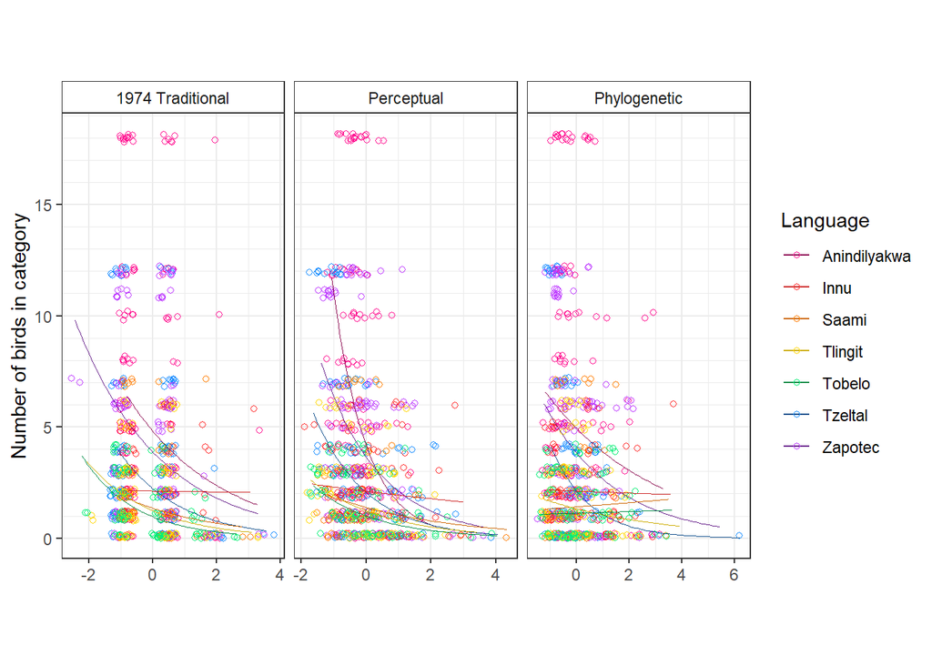

```r
mega_plot
```

# Scaled tSNE plots

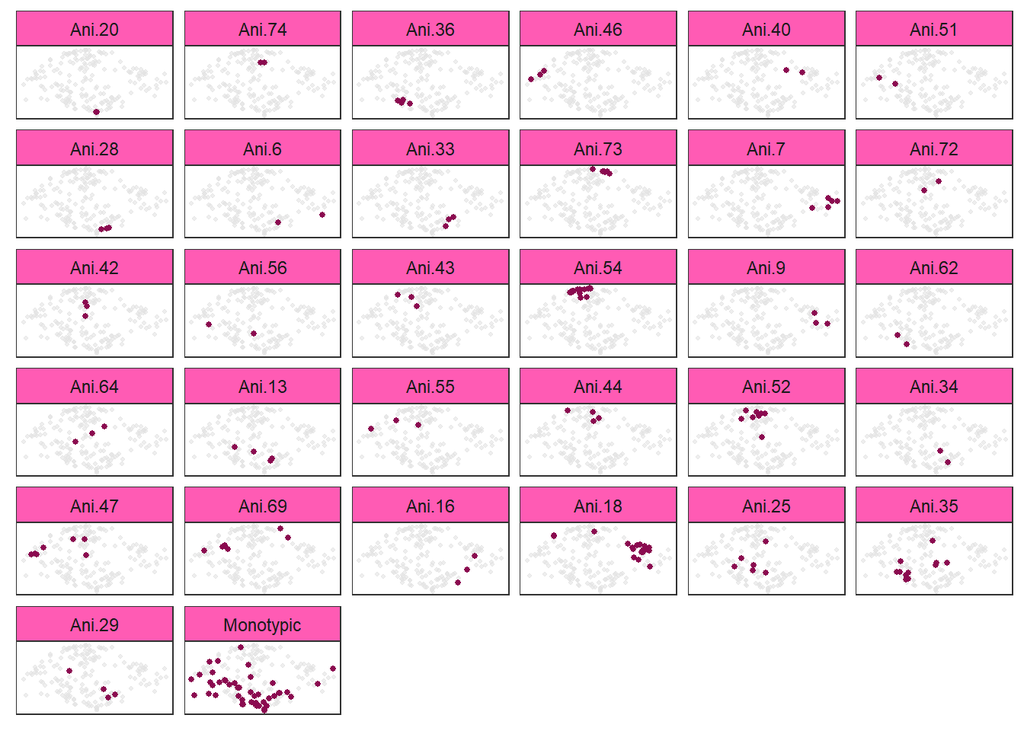

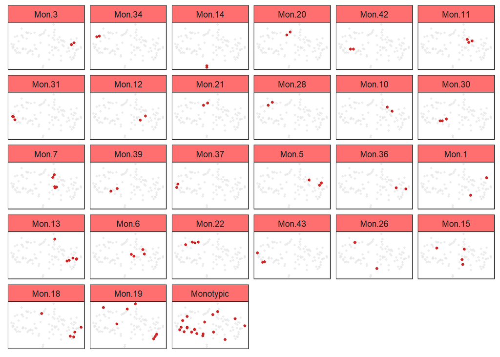

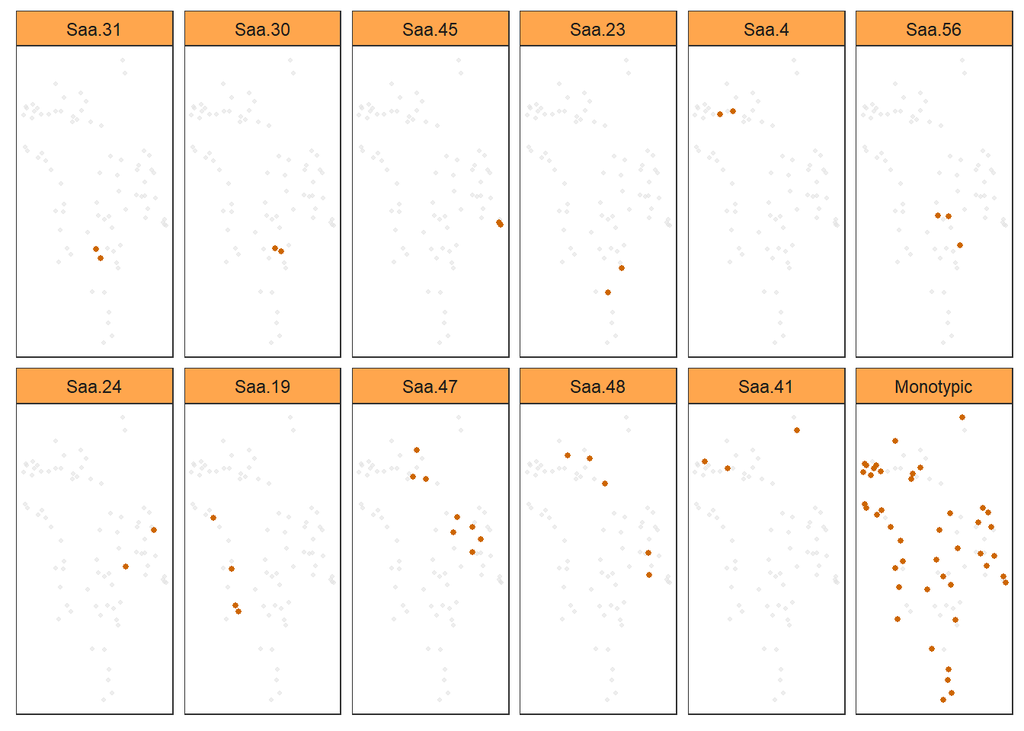

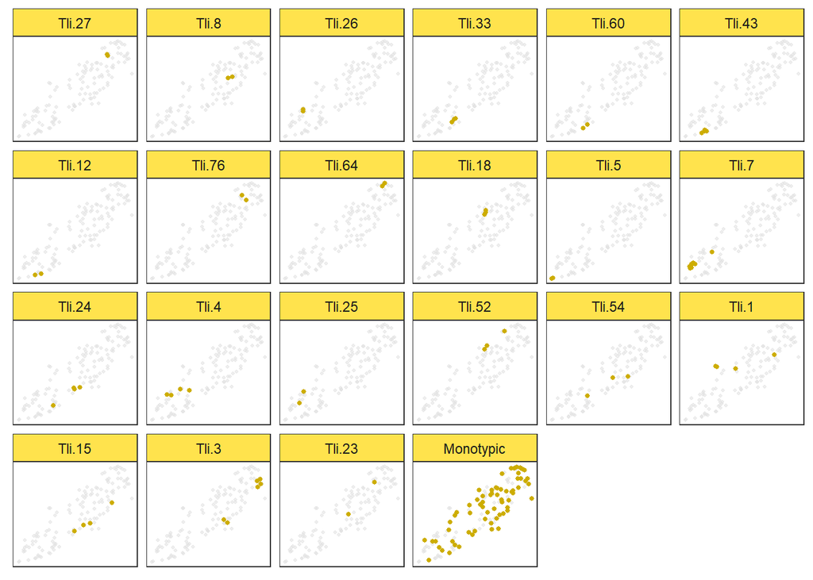

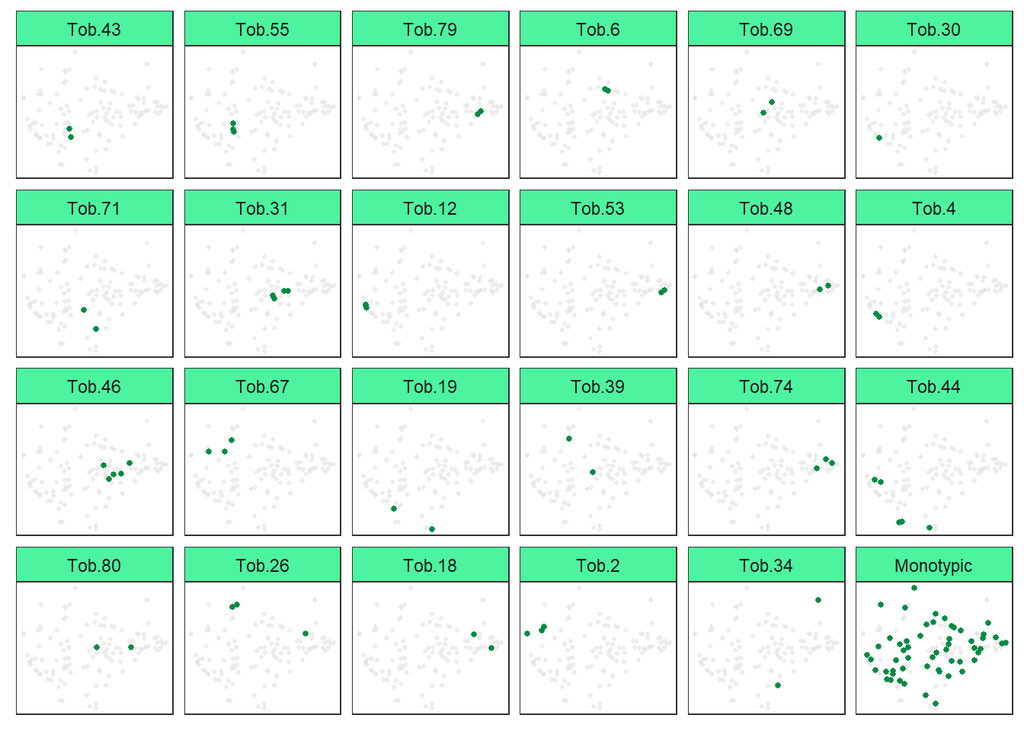

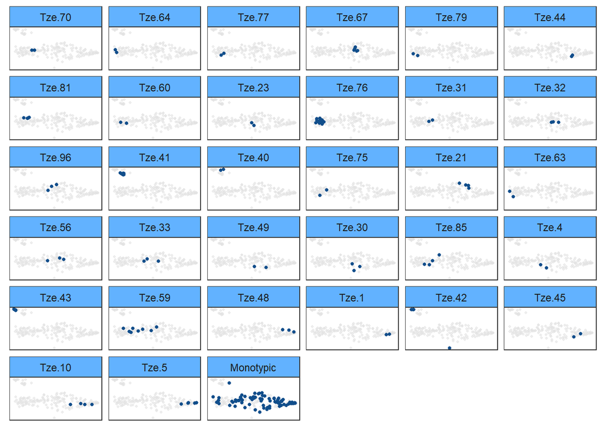

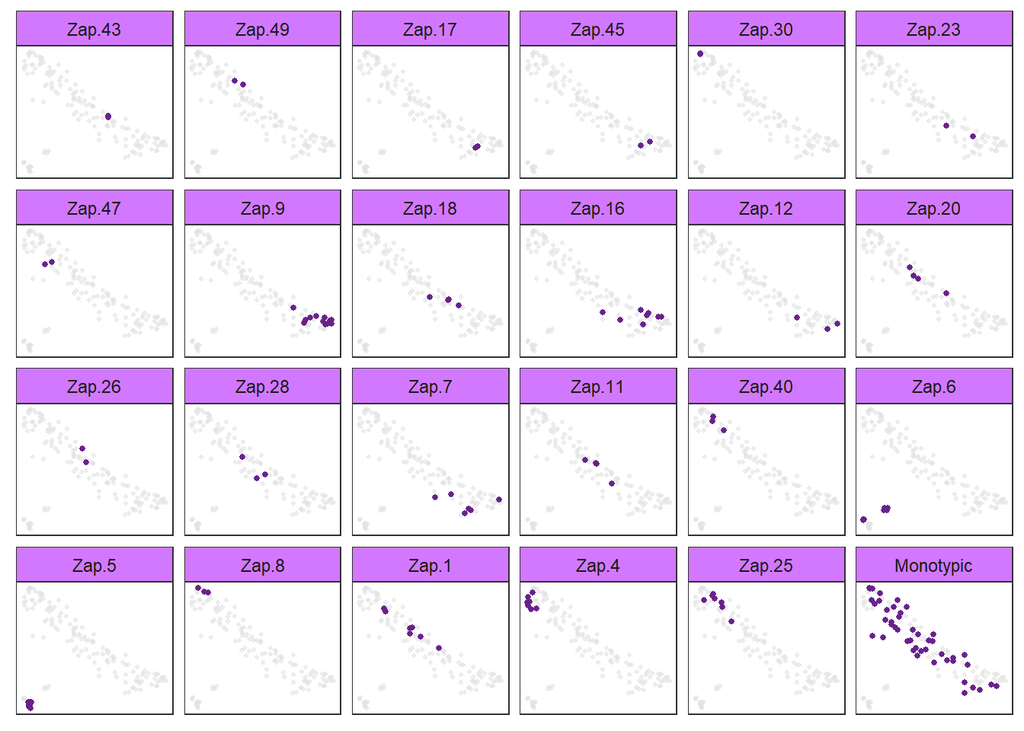

```r
tSNEplotsPer <- list()

for (language in languages) {

  colour_pair <- colour_pairs[[language]]

  language_data <- bird_data %>%
    filter(Language == language & !is.na(tSNE1per)) %>%
    mutate(IndexFG = ifelse(n == 1, "Monotypic", IndexFG),
           IndexFG = factor(IndexFG),
           VarPer = ifelse(IndexFG == "Monotypic", max(VarPer) +1, VarPer)) # easy hack to make sure Monotypic is last facet plotted

  plot <- ggplot() +
    geom_point(data = language_data[,c("tSNE1per","tSNE2per")],
               aes(tSNE1per,tSNE2per),
               colour = "grey89",
               size = 0.8,
               alpha = 0.6) +
    geom_point(data = language_data,
               aes(tSNE1per, tSNE2per),
               size = 1.0,
               colour = colour_pair[2]) +
    facet_wrap(~fct_reorder(IndexFG,VarPer),  ### This was the problem, it was ordered by VarPhy instead of VarPer. I've fixed it, now it needs to go into the paper
               ncol = 6) +
    theme(legend.position = NULL) +
    labs(title = NULL,x = NULL, y = NULL, ) +
    theme_bw() +
    theme(strip.background = element_rect(
      fill = alpha(colour_pair[1],
                   alpha = 0.7)),
          axis.text.x = element_blank(),
          axis.text.y = element_blank(),
          axis.ticks = element_blank(),
          panel.grid = (element_blank()))

    tSNEplotsPer[[language]] <- plot

}

tSNEplotsPer[["All"]] <- NULL



invisible(lapply(tSNEplotsPer, print))
```

```r
  ggsave(here("output/tSNE_plot_Anindilyakwa.png"),
         tSNEplotsPer[["Anindilyakwa"]],
         width = 8,
         height = 8,
         dpi = 500)

    ggsave(here("output/tSNE_plot_Innu.png"),
         tSNEplotsPer[["Innu"]],
         width = 8,
         height = 6.66666,
         dpi = 500)

        # ggsave(here("output/tSNE_plot_Rangi.png"),
        #  tSNEplotsPer[["Rangi"]],
        #  width = 8,
        #  height = 5.333,
        #  dpi = 500)

        ggsave(here("output/tSNE_plot_Saami.png"),
         tSNEplotsPer[["Saami"]],
         width = 8,
         height = 2.6666,
         dpi = 500)

        ggsave(here("output/tSNE_plot_Tlingit.png"),
         tSNEplotsPer[["Tlingit"]],
         width = 8,
         height = 5.3333,
         dpi = 500)

        ggsave(here("output/tSNE_plot_Tobelo.png"),
         tSNEplotsPer[["Tobelo"]],
         width = 8,
         height = 6.6666666,
         dpi = 500)

        ggsave(here("output/tSNE_plot_Tzeltal.png"),
         tSNEplotsPer[["Tzeltal"]],
         width = 8,
         height = 8,
         dpi = 500)

  ggsave(here("output/tSNE_plot_Zapotec.png"),
         tSNEplotsPer[["Zapotec"]],
         width = 8,
         height = 5.33,
         dpi = 500)
```

# tSNE plot for the paper

This is the same tSNE plot from before but with the actual language names put back in. It was hard and annoying. I don’t really want to do it again for all of the other languages.

```r
anindilyakwa_waddy <- read.csv(here("preprocessing/data/anindilyakwa_waddy.csv")) %>%
  mutate(CommonNameOG = ifelse(CommonNameWaddy == "",
                               CommonName,
                               CommonNameWaddy),
         ScientificNameOG = ifelse(ScientificNameWaddy == "",
                                   ScientificName,
                                   ScientificNameWaddy)) %>%
  rename(FolkGeneric = LanguageName) %>%
  group_by(FolkGeneric) %>%
  mutate(n = n()) %>%
  ungroup() %>%
  filter(ScientificName != "Egretta sacra" | FolkGeneric != "amarrirla/amarrarla")

anindilyakwa_data <- bird_data %>%
  filter(Language == "Anindilyakwa") %>%
  left_join(anindilyakwa_waddy %>%
  select(ScientificName,
         FolkGeneric),
            by = c("ScientificName2023" = "ScientificName"),
            keep = FALSE) %>%
  mutate(FolkGeneric = ifelse(is.na(FolkGeneric),
                              anindilyakwa_waddy$FolkGeneric[
                                match(CommonName, anindilyakwa_waddy$CommonName)],
                              FolkGeneric),
         FolkGeneric = ifelse(is.na(FolkGeneric),
                              anindilyakwa_waddy$FolkGeneric[
                                match(ScientificName1974, anindilyakwa_waddy$ScientificName)],
                              FolkGeneric),
         FolkGeneric = ifelse(is.na(FolkGeneric),
                              anindilyakwa_waddy$FolkGeneric[
                                match(ScientificName2021, anindilyakwa_waddy$ScientificName)],
                              FolkGeneric),
         FolkGeneric = ifelse(is.na(FolkGeneric),
                              anindilyakwa_waddy$FolkGeneric[
                                match(ScientificNameV3, anindilyakwa_waddy$ScientificName)],
                              FolkGeneric),
         FolkGeneric = ifelse(is.na(FolkGeneric),
                              anindilyakwa_waddy$FolkGeneric[
                                match(CommonName, anindilyakwa_waddy$CommonNameWaddy)],
                              FolkGeneric)) %>%
  select(-X)

anindilyakwa_data$FolkGeneric[
  anindilyakwa_data$ScientificName2023=="Cacomantis pallidus"] <-
  "duwendira"

anindilyakwa_data$FolkGeneric[
  anindilyakwa_data$ScientificName2023=="Megapodius reinwardt"] <-
  "yinikaburra"

anindilyakwa_data$FolkGeneric[
  anindilyakwa_data$ScientificName2023=="Sphecotheres vieilloti"] <-
  "dijuwarra"

anindilyakwa_data$FolkGeneric[
  anindilyakwa_data$ScientificName2023=="Circus approximans"] <-
  "yinikarrka/yinumabar.darra"

colour_pair <- colour_pairs[["Anindilyakwa"]]

anindilyakwa_data_plot <- anindilyakwa_data %>%
  filter(!is.na(tSNE1per)) %>%
  mutate(FolkGeneric = ifelse(n == 1, "Singleton", FolkGeneric),
         FolkGeneric = sub("\\/.*", "", FolkGeneric),
         FolkGeneric = factor(FolkGeneric),
         VarPer = ifelse(FolkGeneric == "Singleton", max(VarPer) + 1000, VarPer)) # easy hack to make sure Monotypic is last facet plotted

plot <- ggplot() +
  geom_point(data = anindilyakwa_data_plot[,c("tSNE1per","tSNE2per")],
             aes(tSNE1per,tSNE2per),
             colour = "grey89",
             size = 0.8,
             alpha = 0.6) +
  geom_point(data = anindilyakwa_data_plot,
             aes(tSNE1per, tSNE2per),
             size = 1.0,
             colour = colour_pair[2]) +
  facet_wrap(~fct_reorder(FolkGeneric, VarPer),
               ncol = 4) +
    theme(legend.position = NULL) +
    labs(title = NULL,x = NULL, y = NULL, ) +
    theme_bw() +
    theme(strip.background = element_rect(
      fill = alpha(colour_pair[1],
                   alpha = 0.7)),
          axis.text.x = element_blank(),
          axis.text.y = element_blank(),
          axis.ticks = element_blank(),
          panel.grid = (element_blank()))

plot

  ggsave(here("output/tSNE_plot_Anindilyakwa_named.png"),
         plot,
         width = 5.1,
         height = 7,
         dpi = 500)

  plot2 <-  plot + facet_wrap(~fct_reorder(FolkGeneric, VarPer),
               ncol = 8)

  ggsave(here("output/tSNE_plot_Anindilyakwa_named_vertical.png"),
         plot2,
         width = 10,
         height = 4,
         dpi = 500)
```

[output not shown]

# Visualising Phylogenetic Trees

This plots the trees, and I was just noodling around with something that lets you quickly see how the trees interact with the taxonomies (taxonomic and Western Scientific)

```r
# Some functions:

## This one identifies monophyletic Folk Genera - that is, those where everything in the FG shares a common ancestor and there are no other descendants of the ancestor that do not appear in the FG)

check_monophyly <- function(tree, language_data) {

  FGs <- unique(language_data$IndexFG)
  mono_results <- data.frame(FG = character,
                             Monophyletic = logical(),
                             stringsAsFactors = FALSE)

  for (fg in FGs) {

    species <- language_data$ScientificNameV3[language_data$IndexFG == fg]
    is_mono <- is.monophyletic(tree, species)
    mono_results <- rbind(mono_results, data.frame(IndexFG = fg, Monophyletic = is_mono))
  }

  return(mono_results)
}

## This one identifies the most recent common ancestor node for a FG then returns all of the descendant nodes from that node. Not 100% sure if I actually use this anymore, it was mostly to colour branches all the same for monophyletic FGs

family_tree <- function(tree, mono_results, tree_data) {

  tree_data <- tree_data %>% mutate(Orders = NA, Families = NA)
  ancestors <- c()

  for (group in unique(mono_results$IndexFG)) {

    if (any(tree_data$ColGroup == group, na.rm = TRUE)) {

      species <- tree_data %>% filter(IndexFG == group) %>% pull(label)

      if (length(species) > 1) {
      ancestor <- getMRCA(tree, species)
      descendents <- getDescendants(tree, ancestor)

      tree_data <- tree_data %>% mutate(ColGroup = ifelse(is.na(ColGroup) & node %in% descendents, group, ColGroup ))
      ancestors <- c(ancestors, ancestor)

      }
    }
    }

  orders <- c()
    for (group in unique(tree_data$Order2023)) {

      species <- tree_data %>% filter(Order2023 == group) %>% pull(label)

      if (length(species) > 0) {
      ancestor <- getMRCA(tree, species)
      orders <- c(orders, ancestor)

    }
    }

  families <- c()

      for (group in unique(tree_data$Family2023)) {

      species <- tree_data %>% filter(Family2023 == group) %>% pull(label)

      if (length(species) > 0) {
      ancestor <- getMRCA(tree, species)
      families <- c(families, ancestor)

    }
  }

  return(list(tree_data = tree_data,
              ancestors = ancestors,
              orders = orders,
              families = families))
}

tree_plots <- list()

for (language in languages) {

  tree <- read.nexus(here(paste0("data/phylo-tree_", language, ".nex")))
  tree$tip.label <- gsub("_", " ", tree$tip.label)
  colour <- colour_pairs[[language]]

  language_data <- bird_data %>% filter(Language == str_to_title(language))

  # Identify monophyletic FGs

  mono_lang <- check_monophyly(tree, language_data)

  language_data <- language_data %>%
    left_join(mono_lang) %>%
    mutate(ColGroup = ifelse(!Monophyletic,"NonMono",ifelse(n==1,"MonoTypic",IndexFG))) %>%
    mutate(Monotypic = ifelse(n == 1, "Monotypic", NA),
           Point = ifelse(is.na(Monotypic) & !Monophyletic, IndexFG,NA)) %>%
    select(CanonicalName,
           ScientificNameV3,
           IndexFG,
           Family2023,
           Order2023,
           n,
           ColGroup,
           Monophyletic,
           Monotypic,
           Point)

  # Do I need this?
  mono_species <- language_data %>%
    filter(Monophyletic & n != 1) %>%
    select(ScientificNameV3) %>%
    as_tibble()

  tree_data <- as_tibble(tree) %>%
    left_join(language_data, by = c("label" = "ScientificNameV3")) %>%
    group_by(node)

  familytree <- family_tree(tree, mono_lang, tree_data)

  ancestors <- familytree$ancestors
  language_data <- familytree$tree_data
  orders <- familytree$orders
  families <- familytree$families

  tree_plot <- ggtree(tree) %<+% language_data +
    aes(colour = Monotypic) +
    scale_colour_manual(values = colour[2], na.value = "black") +
    geom_tiplab(aes(label = CanonicalName)) +
    theme(legend.position = "none") +
  ## This bit highlights any folk generic category that has a most recent common ancestor whose children all belong to the same FG group.
    # geom_hilight(mapping = aes(subset = node %in% ancestors),
    #              fill = colour[1],
    #              alpha = .3) +
  ## This puts coloured dots on the tips where the colours indicate birds in the same folk generic group.
    # new_scale_colour() +
    # geom_tippoint(aes(
    #   colour = Point,
    #   shape = is.na(Point))) +
    # scale_colour_manual(values = unname(alphabet())) +
    # scale_shape_manual(values = c("TRUE" = NULL, "FALSE" = 19)) +
 ## This part is just a fun thing I was playing with that marks the MRCA for each family and order. It's cool to look at!
    # geom_nodepoint(mapping = aes(subset = node %in% orders),
    #                shape = 1,
    #                colour = "darkviolet",
    #                size = 3) +
    # geom_nodepoint(mapping = aes(subset = node %in% families),
    #                shape = 8,
    #                colour = "green4",
    #                size = 2) +
    scale_x_continuous(expand = expansion(mult = 0.3))

  tree_plots[[language]] <- tree_plot

  ggsave(here(paste0("output/tree_", language, ".pdf")),
         tree_plot,width=13,height=20)

}
```

# Little plots for paper

This is all the code for the little plots in the plot with all the bird pictures in it in the paper. I recently added the Brahminy Kite in but I don’t think I’ll use this version.

### Subset of birds to keep

```r
tokeep <- c("Haliastur sphenurus",
            "Haliastur indus",
            "Lophoictinia isura",
            "Falco subniger",
            "Hieraaetus morphnoides",
            "Falco berigora",
            "Pandion haliaetus",
            "Aprosmictus erythropterus",
            "Ceyx azureus",
            "Dromaius novaehollandiae",
            "Chroicocephalus novaehollandiae",
            "Gymnorhina tibicen")

meta <- bird_data %>%
  filter(Language == "Anindilyakwa" &
           ScientificName2023 %in% tokeep) %>%
  mutate(FG = ifelse(
    IndexFG == "Ani.36",
    "eagle",
    "noteagle"
  ))
```

### Phylogenetic

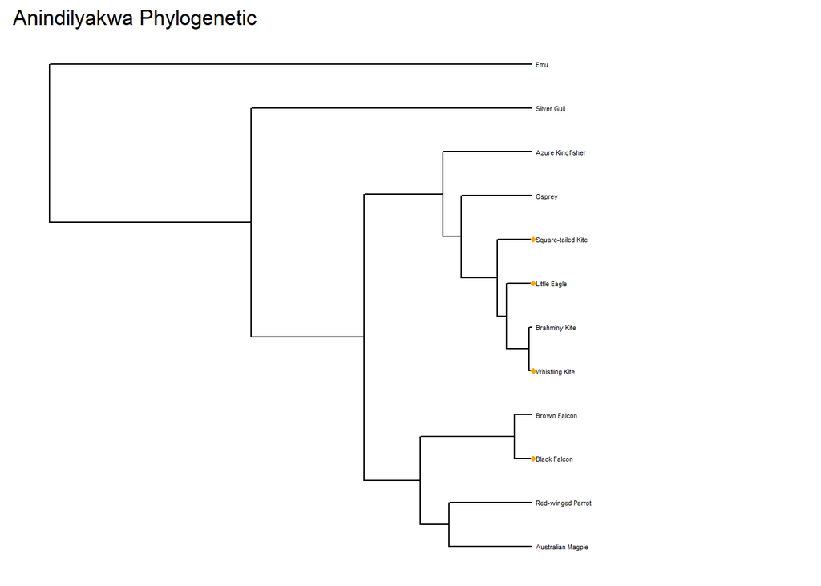

```r
# This stops an error from happening
nodeid.tbl_tree <- utils::getFromNamespace("nodeid.tbl_tree", "tidytree")
rootnode.tbl_tree <- utils::getFromNamespace("rootnode.tbl_tree", "tidytree")
offspring.tbl_tree <- utils::getFromNamespace("offspring.tbl_tree", "tidytree")
offspring.tbl_tree_item <- utils::getFromNamespace(".offspring.tbl_tree_item", "tidytree")
child.tbl_tree <- utils::getFromNamespace("child.tbl_tree", "tidytree")
parent.tbl_tree <- utils::getFromNamespace("parent.tbl_tree", "tidytree")


anindilyakwa_tree <- read.nexus(file = here("data/phylo-tree_anindilyakwa.nex"))

anindilyakwa_tree$tip.label <- gsub("_", " ", anindilyakwa_tree$tip.label)

subsetPhy <- drop.tip(anindilyakwa_tree,
                   anindilyakwa_tree$tip.label[
  -match(meta$ScientificNameV3, anindilyakwa_tree$tip.label)])

metaPhy <- meta %>%
  select(ScientificNameV3, CommonName, FG)

phylo_tree_plot <-
  ggtree(subsetPhy, ladderize = FALSE)%<+%
  metaPhy +
  geom_tiplab(aes(label = CommonName), size = 1.5) +
  geom_tippoint(aes(colour = FG, shape = FG, size = FG)) +
  scale_colour_manual(values = c("orange", "white")) +
  scale_shape_manual(values = c(18, 20)) +
  scale_size_manual(values = c(1.5, 1)) +
  labs(title = "Anindilyakwa Phylogenetic") +
  theme(legend.position = "none") +
  coord_cartesian(xlim = c(0,1.5))

ggsave(here("output/si_anindilyakwa_phylo_plot.png"),
       phylo_tree_plot,
       width = 4.1,
       height = 4.5,
       dpi = 300)

phylo_tree_plot
```

### Clements 23

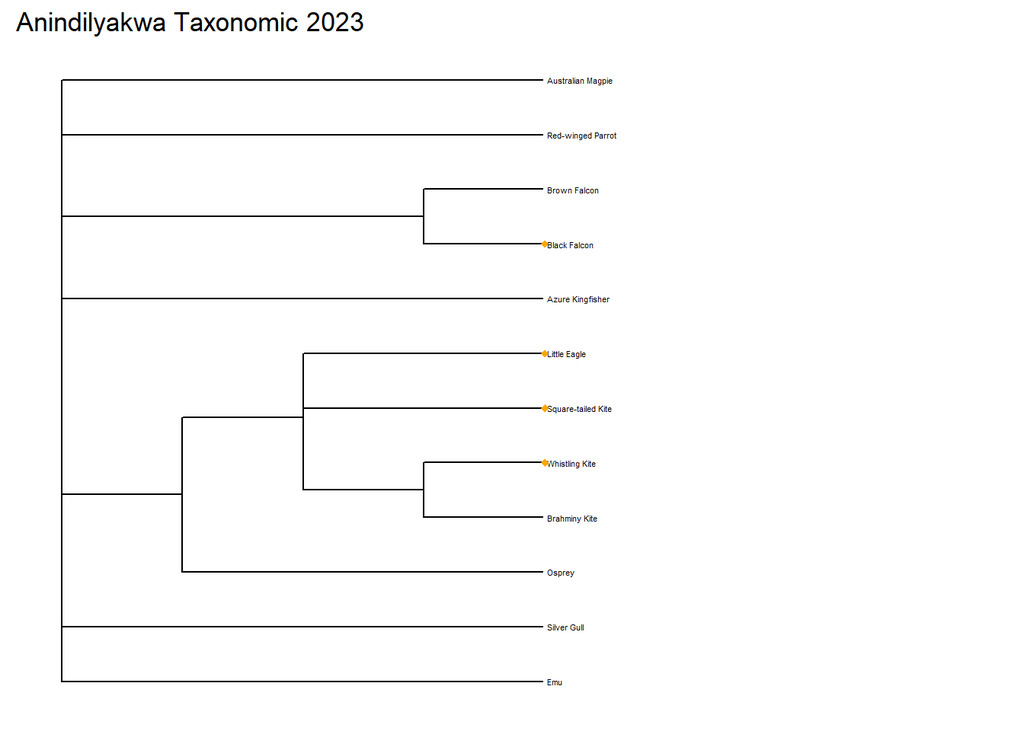

```r
# For this one I have to create a new tree because dropping tips is doing something weird to the tree.

# Import data

clements_2023 <- read.csv(here("preprocessing/data/clements_2023.csv"))

family_order74 <- read.csv(here("preprocessing/data/clements_1974_orders.csv"))

  family_order23 <- clements_2023 %>%
    mutate(Family2023 = str_trim(str_extract(family,"\\b\\w+"))) %>%
    select(Family2023) %>%
    filter(Family2023 %in% meta$Family2023) %>%
    mutate(Family2023 = as.factor(Family2023))

  meta23 <- meta %>%
    mutate(Class = "Aves") %>%
    select(ScientificName2023,
           Genus2023,
           Family2023,
           Order2023,
           Class) %>%
    mutate_all(as.factor) %>%
    arrange(match(Family2023, family_order23$Family2023))

  tree23 <- as.phylo(~Class/Order2023/Family2023/Genus2023/ScientificName2023,
                        data = meta23) %>%
    compute.brlen(.2) %>%
    as.ultrametric()

  # Had to bully some things into doing my bidding. It's not dodgy

  # tree23$edge.length[10] <- tree23$edge.length[10] + .4
  tree23$edge.length[12] <- tree23$edge.length[12] + .4
  # tree23$edge.length[1] <- tree23$edge.length[1] + .2
  # tree23$edge.length[2] <- tree23$edge.length[2] + .2
  # tree23$edge.length[4] <- tree23$edge.length[4] + .2
  # tree23$edge.length[6] <- tree23$edge.length[6] + .2
  # tree23$edge.length[7] <- tree23$edge.length[7] + .2
  # tree23$edge.length[8] <- tree23$edge.length[8] + .2
  # tree23$edge.length[9] <- tree23$edge.length[9] + .2
  tree23$edge.length[13:14] <- tree23$edge.length[13:14] - .4

meta23 <- meta %>%
  arrange(match(Family2023, family_order23$Family2023)) %>%
  select(ScientificName2023,
         CommonName,
         FG)

clements_23_tree_plot <-
  ggtree(tree23, ladderize = FALSE) %<+%
  meta23 +
  geom_tiplab(aes(label = CommonName), size = 1.5) +
  geom_tippoint(aes(colour = FG, shape = FG, size = FG)) +
  scale_colour_manual(values = c("orange", "white")) +
  scale_shape_manual(values = c(18, 20)) +
  scale_size_manual(values = c(1.5, 1)) +
  labs(title = "Anindilyakwa Taxonomic 2023") +
  theme(legend.position = "none") +
  coord_cartesian(xlim = c(0,1.5))

ggsave(here("output/si_anindilyakwa_23_plot.png"),
       clements_23_tree_plot,
       width = 4.1,
       height = 4.5,
       dpi = 300)

clements_23_tree_plot
```

### Clements 74

Here’s the same taxonomic tree for the 1974 Clements

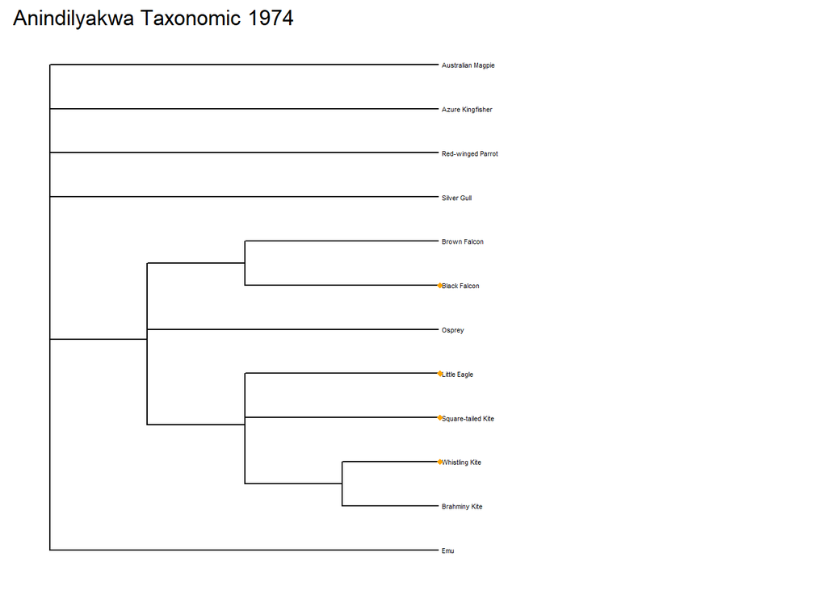

```r
# This is to put the birds in the right order in the tree
family_order74 <- family_order74 %>%
  filter(Family %in% meta$Family1974)

  meta74 <- meta %>%
    mutate(Class = "Aves") %>%
    select(ScientificName1974,
           Genus1974,
           Family1974,
           Order1974,
           Class) %>%
    mutate_all(as.factor) %>%
    arrange(match(Family1974, family_order74$Family))

  tree74 <- as.phylo(~Class/Order1974/Family1974/Genus1974/ScientificName1974,
                        data = meta74) %>%
    compute.brlen(.2) %>%
    as.ultrametric()


  tree23$edge.length[12] <- tree23$edge.length[12] + .4
  tree23$edge.length[13:14] <- tree23$edge.length[13:14] - .4

meta74 <- meta %>%
  arrange(match(Family1974, family_order74$Family)) %>%
  select(ScientificName1974,
         CommonName,
         FG)

clements_74_tree_plot <-
  ggtree(tree74, ladderize = FALSE) %<+%
  meta74 +
  geom_tiplab(aes(label = CommonName), size = 1.5) +
  geom_tippoint(aes(colour = FG, shape = FG, size = FG)) +
  scale_colour_manual(values = c("orange", "white")) +
  scale_shape_manual(values = c(18, 20)) +
  scale_size_manual(values = c(1.5, 1)) +
  labs(title = "Anindilyakwa Taxonomic 1974") +
  theme(legend.position = "none") +
  coord_cartesian(xlim = c(0,1.5))

ggsave(here("output/anindilyakwa_74_plot.png"),
       clements_74_tree_plot,
       width = 4.1,
       height = 4.5,
       dpi = 300)

clements_74_tree_plot
```